# FigureYa254scViolin

Zongcheng Li

2025-5-20

# 需求描述

这个小提琴图很高大上，适于差异比较展示。

# Requirement Description

This violin diagram is very advanced and suitable for comparing differences.

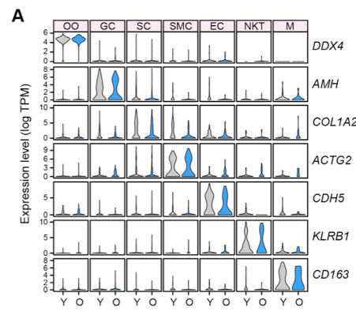

Figure S4. Integrative Analysis of Aging-Associated Differentially Expressed Genes with Genes from GenAge or POF/POI Database, Related to Figure 4 (A) Violin plots showing **expression levels of marker genes for each cell type in young (Y) and old (O) monkey ovaries**.

# 应用场景

三种特征同时对比展示。就像例文用该图对比展示了三个特征之下的基因表达量分布：细胞类型、marker基因、年龄。

这里输入数据有两种形式任你选，跟单细胞数据无缝对接，对非单细胞数据非常友好。

我们众筹过例文的几个Figure：

- Figure 1H，热图和气泡图对应展示表达谱和基因功能富集分析结果，可参考FigureYa206scHeatmap；
- Figure 3AB，从PCA结果就能看出基因表达模式跟细胞类型的关系，可参考FigureYa222PCAgene；
- Figure 4B，用两种颜色展示上调和下调的基因，可参考FigureYa232scRankHeatmap；

另外，Figure S6H用颜色和形状展示两个层面的分组信息，画法可参考FigureYa101PCA。

# Application Scenarios

The three characteristics are displayed in comparison at the same time. Just like the example in this diagram, the distribution of gene expression under three characteristics is compared: cell type, marker gene, and age.

There are two forms of input data for you to choose from, which is seamless with single-cell data and very friendly to non-single-cell data.

Here are a few examples of how we crowdfunded:

- Figure 1H, heat map and bubble map correspond to the results of expression profiling and gene function enrichment analysis, please refer to FigureYa206scHeatmap;
- Figure 3AB, the relationship between gene expression patterns and cell types can be seen from the PCA results, please refer to FigureYa222PCAgene;
- Figure 4B, showing the up- and down-regulated genes in two colors, see FigureYa232scRankHeatmap;

In addition, Figure S6H uses color and shape to display the grouping information at two levels, which can be drawn by referring to FigureYa101PCA.

# 环境设置

使用国内镜像安装包

# Environment settings

Use the domestic mirror installation package

```r
options("repos"= c(CRAN="https://mirrors.tuna.tsinghua.edu.cn/CRAN/"))
options(BioC_mirror="http://mirrors.tuna.tsinghua.edu.cn/bioconductor/")
```

加载包 load packages

```r
library(Seurat)
library(magrittr)
library(tidyverse)
```

```r
library(ggplot2)
library(ggpubr)
library(rstatix)
library(RColorBrewer)
Sys.setenv(LANGUAGE = "en") #显示英文报错信息 # error messages are displayed in English
options(stringsAsFactors = FALSE) #禁止chr转成factor # chr is not allowed to be converted to factor
```

# 输入文件

单细胞和非单细胞数据任选其一：

- 单细胞数据。sc.seurat.Rdata，单细胞RNA-seq预处理获得的文件。文件较大，已上传至微云https://share.weiyun.com/vZiSM9pB。怎样获得这个文件？拖到文末看“附：单细胞RNA-seq数据预处理”
- 非单细胞数据。easy_input.csv，只要你的数据也有三种特征，整理成的easy_input.csv的样子，就可以画这样的图。

# Input files

Choose between single-cell and non-single-cell data:

- Single-cell data. sc.seurat.Rdata, file obtained from single-cell RNA-seq pretreatment. The file size is large and has been uploaded to the Weiyun https://share.weiyun.com/vZiSM9pB. How do I get this document? Drag to the end of the article to see “Attached: Single-cell RNA-seq data preprocessing”
- Non-single-cell data. easy_input.csv, as long as your data also has three characteristics, organized into a easy_input.csv appearance, you can draw such a graph.

## Single-cell data

```r
load("sc.seurat.Rdata")
markers <- c("DDX4", "AMH", "COL1A2", "ACTG2", "CDH5", "KLRB1", "CD163")

df <- FetchData(sc, vars = c(markers, "aging", "cluster_short")) %>%
  reshape2::melt(id.vars = c("aging", "cluster_short"),
                 variable.name = "gene",
                 value.name = "expression") %>%
  mutate(aging = factor(aging, levels = c("Y", "O")),
         cluster_short = factor(cluster_short, levels = c("OO","GC", "SC", "SMC",  "EC", "NKT", "M")))

# 保存到文件，便于套用格式
# Save to a file for easy formatting
write.csv(df, "easy_input.csv", quote = F, row.names = F)
```

## 非单细胞数据

easy_input.csv，前三列是你想用来分组的三种特征，最后一列为具体数值，图中会展示该数值的分布。

## Non-single-cell data

easy_input.csv, the first three columns are the three features you want to group, and the last column is a specific value, which is shown in the graph.

```r
df <- read.csv("easy_input.csv", header = T)

# 按自己的要求排序，该顺序对应图中的顺序
# Sort according to your own requirements, the order corresponds to the order in the figure
df$aging <- factor(df$aging, levels = c("Y", "O"))
df$cluster_short <- factor(df$cluster_short, levels = c("OO","GC", "SC", "SMC",  "EC", "NKT", "M"))
df$gene <- factor(df$gene, levels = c("DDX4", "AMH", "COL1A2", "ACTG2", "CDH5", "KLRB1", "CD163"))

head(df)
```

```
##   aging cluster_short gene expression
## 1     Y           SMC DDX4          0
## 2     Y           SMC DDX4          0
## 3     Y           SMC DDX4          0
## 4     Y            SC DDX4          0
## 5     Y           SMC DDX4          0
## 6     Y           SMC DDX4          0
```

# 开始画图

图中会横向展示cluster_short，纵向展示 gene，每个小格内以aging分组，绘制基因表达量分布。

# Start drawing

The figure shows cluster_short horizontally and genes vertically, and each cell is grouped by aging to plot the distribution of gene expression.

## Reproduce the original text

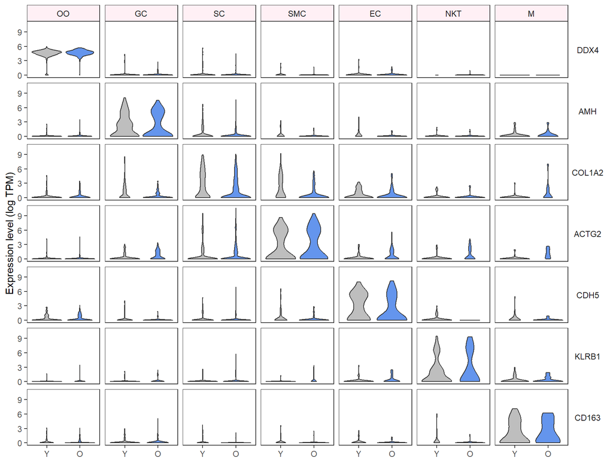

```r
ggplot(data = df, mapping = aes(aging, expression, fill = aging)) +
  geom_violin(show.legend = F) +
  scale_fill_manual(values = c("grey", "cornflowerblue")) + # 两组分别填充灰色和蓝色 # The two groups are filled with gray and blue, respectively
  facet_grid(gene~cluster_short) +
  theme_bw() +
  xlab("") +
  ylab("Expression level (log TPM)") +
  theme(panel.grid = element_blank(),
        strip.background.x = element_rect(fill = "lavenderblush"), # 顶部填充粉色 # Top padded pink
        strip.text.y = element_text(angle = 0),
        strip.background.y = element_blank())
```

```r
ggsave("scViolin.pdf", width = 9, height = 7)
```

## 美化版

小伙伴嫌原图配色丑，我们修改一下颜色。

## Beautified version

My friend thinks the color of the original picture is ugly, so let’s modify the color.

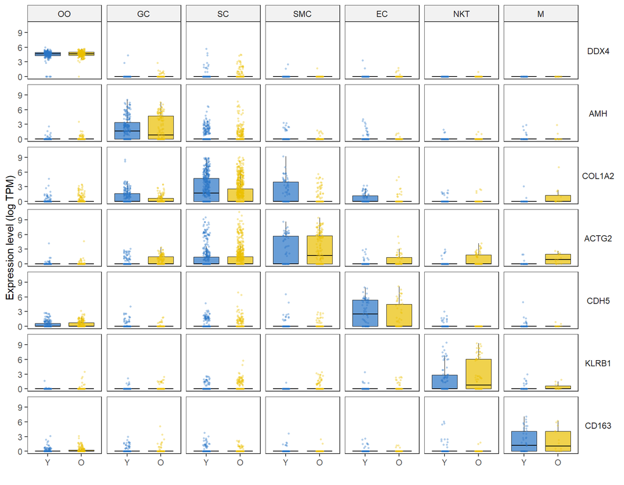

```r
ggplot(df, mapping = aes(aging, expression, fill = aging, color = aging)) +
  #geom_violin(show.legend = F) + # 画violin # Draw violin
  scale_fill_manual(values = c("#2874C5", "#EABF00")) + # 两组分别填充蓝色和黄色 # The two groups are filled with blue and yellow, respectively
  scale_color_manual(values = c("#2874C5", "#EABF00")) + # 边框跟填充颜色一致 # The border is the same color as the fill

  # 如果你喜欢，可以叠加box plot
  # If you like, you can overlay box plots
  geom_boxplot(outlier.size = -1,
               show.legend = FALSE, # 不显示图例 # Legend is not displayed
               color="black", lwd=0.2, # 线的粗细 # The thickness of the line
               alpha = 0.7) + # 透明化 # Transparency
  # 还可以叠加散点 # Scatters can also be overlayed
  geom_point(shape = 21, size=.6, # 点的形状和大小 # The shape and size of the dots
             show.legend = FALSE, # 不显示图例 # Legend is not displayed
             position = position_jitterdodge(),
             alpha = 0.3)+
  # 甚至可以注释掉上面geom_violin那行，不画violin，只画box和散点
  # You can even comment the line of geom_violin, don't draw violin, only box and scatter

  facet_grid(gene ~ cluster_short) +
  theme_bw() +
  xlab("") +
  ylab("Expression level (log TPM)") +
  theme(panel.grid = element_blank(),
        strip.background.x = element_rect(fill = "grey95"), # 顶部填充浅灰色 # The top is filled with light gray
        strip.text.y = element_text(angle = 0),
        strip.background.y = element_blank())
```

```r
ggsave("scViolin_color.pdf", width = 9, height = 7)
```

## 加强版

借助ggpubr加上pvalue或显著性星标*，分面加pvalue的方法参考了这篇https://www.datanovia.com/en/blog/how-to-add-p-values-to-ggplot-facets/

## Enhanced

With the help of ggpubr plus pvalue or salient star*, the method of adding pvalue to facets refers to this https://www.datanovia.com/en/blog/how-to-add-p-values-to-ggplot-facets/

```r
stat.test <- df %>%
  group_by(cluster_short, gene) %>%
  t_test(expression ~ aging) %>%
  adjust_pvalue(method = "bonferroni") %>%
  add_significance()

stat.test
```

```
## # A tibble: 49 × 12
##    cluster_short gene   .y.    group1 group2    n1    n2 statistic    df       p
##    <fct>         <fct>  <chr>  <chr>  <chr>  <int> <int>     <dbl> <dbl>   <dbl>
##  1 OO            DDX4   expre… Y      O        191   227  -1.96     306. 5.14e-2
##  2 OO            AMH    expre… Y      O        191   227  -0.888    415. 3.75e-1
##  3 OO            COL1A2 expre… Y      O        191   227  -2.72     410. 6.76e-3
##  4 OO            ACTG2  expre… Y      O        191   227  -0.00534  406. 9.96e-1
##  5 OO            CDH5   expre… Y      O        191   227   0.144    394. 8.86e-1
##  6 OO            KLRB1  expre… Y      O        191   227  -1.79     293. 7.39e-2
##  7 OO            CD163  expre… Y      O        191   227  -1.38     415. 1.69e-1
##  8 GC            DDX4   expre… Y      O        209   149  -1.09     343. 2.75e-1
##  9 GC            AMH    expre… Y      O        209   149  -0.202    298. 8.4 e-1
## 10 GC            COL1A2 expre… Y      O        209   149   4.85     336. 1.92e-6
## # ℹ 39 more rows
## # ℹ 2 more variables: p.adj <dbl>, p.adj.signif <chr>
```

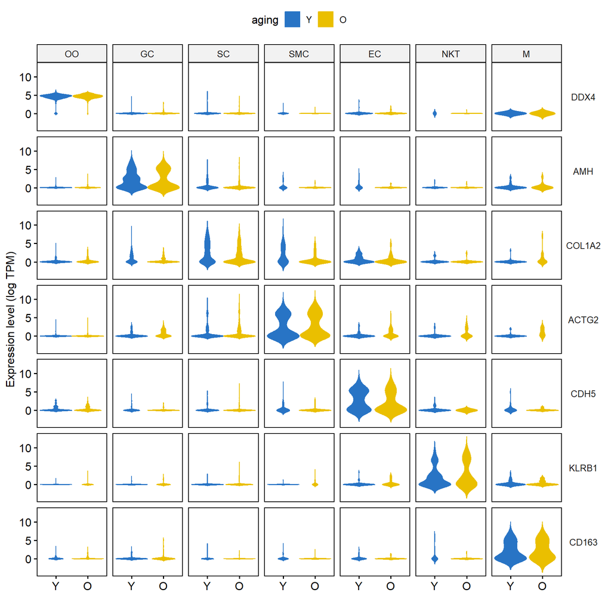

```r
# cutpoints: 0, 1e-04, 0.001, 0.01, 0.05, 1
# symbols: "****", "***", "**", "*", "ns"

stat.test <- stat.test %>% add_xy_position(x = "aging")

v1 <- ggviolin(df, x = "aging", y = "expression",
               fill = "aging",
               color = "aging", # 如果想要黑色边框，就删掉这行 # If you want a black border, delete this line
               facet = c("gene","cluster_short")) +
  scale_fill_manual(values = c("#2874C5", "#EABF00")) +
  scale_color_manual(values = c("#2874C5", "#EABF00")) + #边框跟填充色一致 # The border is the same as the fill color
  xlab("") +
  ylab("Expression level (log TPM)") +
  theme(panel.grid = element_blank(),
        strip.text.y = element_text(angle = 0),
        strip.background.x = element_rect(fill = "grey95"), # 顶部填充浅灰色 # The top is filled with light gray
        strip.background.y = element_blank())
v1
```

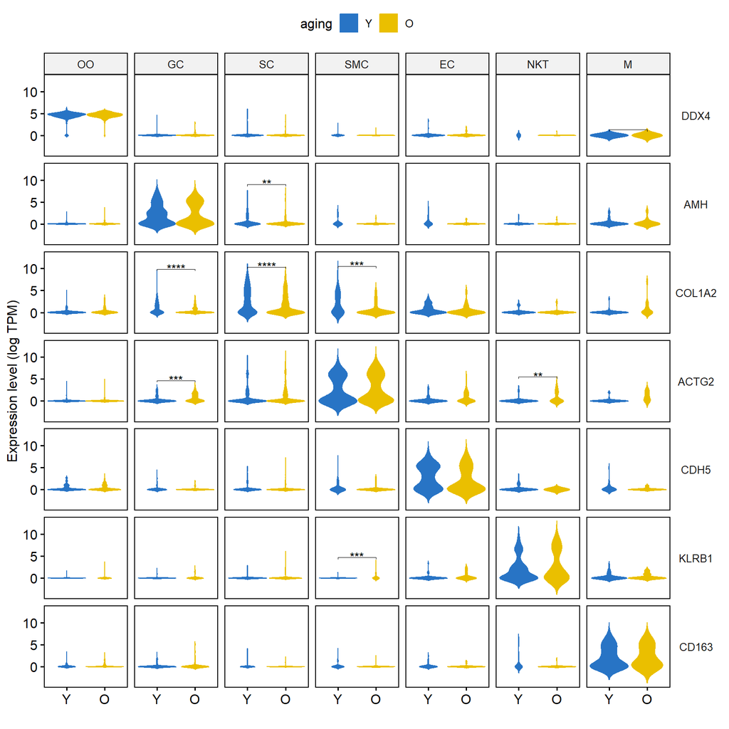

```r
# 显著标星*
# Prominently Starred*
v1 + stat_pvalue_manual(stat.test, hide.ns = TRUE) #显著性星标 # Distinctive star
```

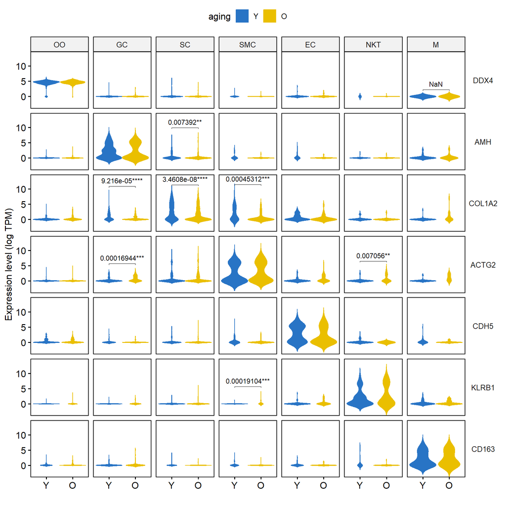

```r
ggsave("scViolin_plus.pdf", width = 9, height = 9)

# 还可以同时显示pvalue数值和标星*
# It is also possible to display both pvalue and star*
v1 +
  stat_pvalue_manual(stat.test,
                     bracket.nudge.y = 1,
                     hide.ns = TRUE, #不显示不显著的，这里有个特殊情况是图右上角M ~ DDX4出现了NaN，是因为该组所有样本表达量都为0 # The non-significant ones will not be displayed, and there is a special case here that NaN appears in M ~ DDX4 in the upper right corner of the figure, because the expression level of all samples in this group is 0
                     label = "{p.adj}{p.adj.signif}", # pvalue和星标 # pvalue and star
                     label.size = 3, # pvalue字的大小 # The size of the pvalue word
                     vjust = -0.5) + # pvalue的上（负）下位置 # The upper (negative) lower position of the pvalue
  scale_y_continuous(expand = expansion(mult = c(0, 0.1))) #给pvalue文字留足空间 # Leave enough space for pvalue text
```

# 后期处理

输出的pdf文件是矢量图，可以用Illustrator等软件打开，编辑图形和文字。

# Post-processing

The output pdf file is a vector illustration that can be opened with software such as Illustrator to edit graphics and text.

# 附：单细胞RNA-seq数据预处理

以下代码出自`FigureYa206scHeatmap`，会生成`sc.seurat.Rdata`文件，可作为以上代码的输入文件。

# Attached: Single-cell RNA-seq data preprocessing

The following code is from ‘FigureYa206scHeatmap’ and will generate a ‘sc.seurat.Rdata’ file, which can be used as an input file for the above code.

## 下载单细胞RNA-seq数据(已从微云下载，故此处不再下载)

1. UMI count，从NCBIGSE130664下载：`GSE130664_merge_UMI_count.txt.gz`文件。

## Download single-cell RNA-seq data (downloaded from Microcloud, so no more download here)

1. UMI count, download from NCBIGSE130664: ‘GSE130664_merge_UMI_count.txt.gz’ file.

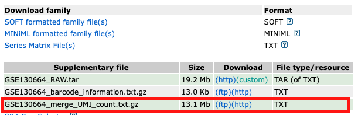

```r
#download.file("https://www.ncbi.nlm.nih.gov/geo/download/?acc=GSE130664&format=file&file=GSE130664%5Fmerge%5FUMI%5Fcount%2Etxt%2Egz",
              #destfile = "GSE130664_merge_UMI_count.txt.gz")
```

2. metadata，从[例文的](https://doi.org/10.1016/j.cell.2020.01.009)Supplementary Tables获得：`1-s2.0-S0092867420300568-mmc1.xlsx`
3. metadata, obtained from (https://doi.org/10.1016/j.cell.2020.01.009) Supplementary Tables in [example text]: ‘1-s2.0-S0092867420300568-mmc1.xlsx’

## Read data

```r
umi <- read.table(file = gzfile("GSE130664_merge_UMI_count.txt.gz"), header = T, row.names = 1, sep = "\t")
qc <- readxl::read_excel("1-s2.0-S0092867420300568-mmc1.xlsx", sheet = 2)
meta <- readxl::read_excel("1-s2.0-S0092867420300568-mmc1.xlsx", 3) %>%
  column_to_rownames("cell")
```

## Data preprocessing

See Methods:  
QUANTIFICATION AND STATISTICAL ANALYSIS -> Single-Cell RNA-Seq Data Processing

```r
# QC of Cells
cells <- qc %>%
  filter(`Mapping rate` >= 0.2 &
           `Gene number` >= 700 &
           UMI >= 3000) %>%
  pull(Rename)

# seurat object
sc <- CreateSeuratObject(counts = umi[,cells], meta.data = meta)

# expression transformation
sc@assays$RNA$data <- sc@assays$RNA$counts %>%
  apply(2, function(x){
    log2(10^5*x/sum(x)+1)
    })

# remove other cells
sc <- sc[,sc$cluster != "other"]

# 给cluster改名
# Rename the cluster
sc$cluster_short <- factor(
  plyr::mapvalues(sc$cluster,
                  c("Oocyte", "Natural killer T cell", "Macrophage",
                    "Granulosa cell", "Endothelial cell",
                    "Smooth muscle cell", "Stromal cell"),
                  c("OO", "NKT", "M", "GC", "EC", "SMC", "SC")),
  levels = c("OO", "NKT", "M", "GC", "EC", "SMC", "SC"))

# 给cluster自定义颜色
# Customize the color for the cluster
cluster_colors <- setNames(brewer.pal(7, "Set1"), levels(sc$cluster_short))

# 保存一下，便于停下来接着跑
# Save it so you can stop and run
#save(sc, cluster_colors, file = "sc.seurat.Rdata")

# 还可以把表达矩阵输出到文件
# It is also possible to output the expression matrix to a file
#write.csv(sc@assays$RNA@data, "easy_input_expr.csv", quote = F)
```